# bee

```python
%matplotlib inline
import os
from datetime import datetime

from descartes import PolygonPatch
import matplotlib as mpl
from matplotlib.collections import PatchCollection
import matplotlib.pyplot as plt
import numpy as np
import pandas as pd
import requests
from shapely import geometry as sg, wkt
```

Choose a matplotlib style, see `plt.style.available` for all the available styles.

```python
plt.style.use('seaborn')
```

The [GBIF Web API](http://www.gbif.org/developer/summary) utilizes pagination to split up the returned JSON records, so we need to request each successive page to gather all the results. This helper class will handle that.

```python
class GBIFRequest(object):
    """GBIF requests with pagination handling."""
    url = 'http://api.gbif.org/v1/occurrence/search'

    def fetch(self, params):
        resp = requests.get(self.url, params=params)
        return resp.json()

    def get_pages(self, params):
        params = dict({'limit': 100, 'offset': 0}, **params)
        data = {'endOfRecords': False}
        while not data['endOfRecords']:
            data = self.fetch(params)
            params['offset'] += params['limit']
            yield data
```

Request the available occurrence records for a particular species and plot their locations.

```python
req = GBIFRequest()
params = {'scientificName': 'Argia agrioides'}
pages = req.get_pages(params)
# Filter all the returned records for valid locations.
records = [rec for page in pages for rec in page['results']
           if rec.get('decimalLatitude')]
# Make a list of coordinate pairs for plotting.
coords = [(r['decimalLongitude'], r['decimalLatitude']) for r in records]
xs, ys = zip(*coords)
```

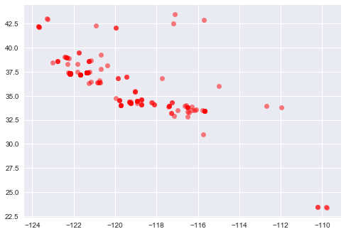

```python
plt.plot(xs, ys, 'ro', alpha=0.5)
```

Request GeoJSON for all reserves and plot the locations.

```python
url = 'https://ecoengine.berkeley.edu/api/layers/reserves/features/'
reserves = requests.get(url, params={'page_size': 30}).json()
geoms = {feat['properties']['name']: sg.asShape(feat['geometry']) for feat in reserves['features']}
```

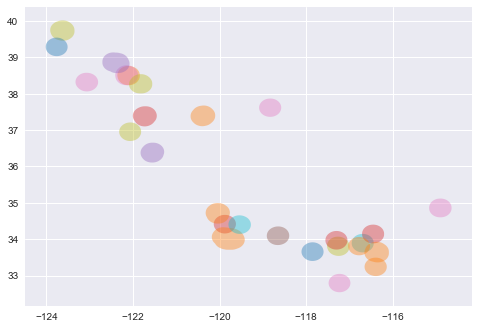

```python
# Buffer reserves so we can view them at a regional scale.
patches = [PolygonPatch(geom.buffer(0.25)) for geom in geoms.values()]
fig, ax = plt.subplots()
colors = 100 * np.random.rand(len(patches))
p = PatchCollection(patches, cmap='tab10', alpha=0.4)
p.set_array(np.array(colors))
ax.add_collection(p)
ax.autoscale()
```

Zoom in to the Santa Cruz Island Reserve where we have a single occurrence.

```
(33.9592132555463, 34.077671049810775)
```

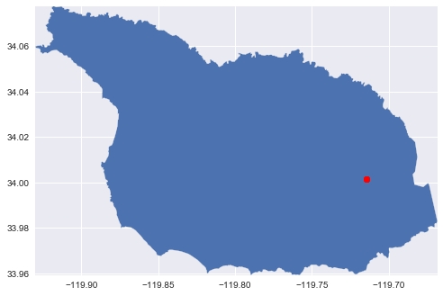

```python
fig, ax = plt.subplots()
g = geoms['Santa Cruz Island Reserve']
poly = PolygonPatch(g)
ax.add_patch(poly)
ax.plot(xs, ys, 'ro', clip_path=poly)
xmin, ymin, xmax, ymax = g.bounds
ax.set_xlim(xmin, xmax)
ax.set_ylim(ymin, ymax)
```

Parse the WKT geometry for Blodgett, Hopland, and Sagehen stations and plot them individually.

```python
station_urls = {
    'Blodgett': 'https://raw.githubusercontent.com/BNHM/spatial-layers/master/wkt/BlodgettForestResearchStation.wkt',
    'Hopland': 'https://raw.githubusercontent.com/BNHM/spatial-layers/master/wkt/HoplandREC.wkt',
    'Sagehen': 'https://raw.githubusercontent.com/BNHM/spatial-layers/master/wkt/SagehenCreekFieldStation.wkt'
}
stn_features = [{'id': name, 'geometry': wkt.loads(requests.get(url).text)}
                for name, url in station_urls.items()]
# Reduce geometric complexity, we need smaller geometry serializations to circumvent
# URL length restrictions.
tol = .0001
for feat in stn_features:
    feat['geometry'] = feat['geometry'].buffer(tol).simplify(tol)
```

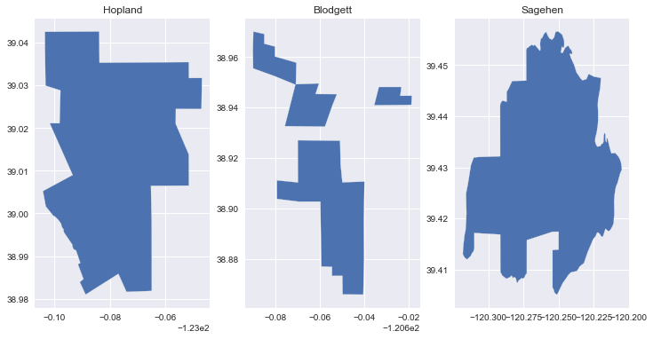

```python
f, axes = plt.subplots(1, len(stn_features))
f.set_size_inches((12, 6))

for ax, feat in zip(axes, stn_features):
    ax.add_patch(PolygonPatch(feat['geometry']))
    ax.set_title(feat['id'])
    ax.autoscale()
```

Use the [Cal-Adapt](http://api.cal-adapt.org/api/) web API to access a remote raster data source and preview a rendered image.

```python
url = 'http://api.cal-adapt.org/api/series/tasmax_year_CanESM2_rcp85/rasters/'
json = requests.get(url).json()
tifurl = json['results'][0]['image']
title = json['results'][0]['slug']
```

```python
import greenwich
```

```python
with greenwich.open(tifurl) as r:
    arr = r.masked_array()
```

Visualize the resulting masked array. The array values are maximum temperature in Kelvin.

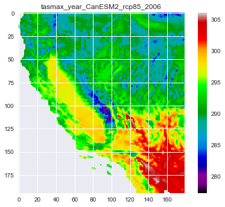

```python
plt.imshow(arr, cmap='spectral')
plt.title(title)
plt.colorbar()
```

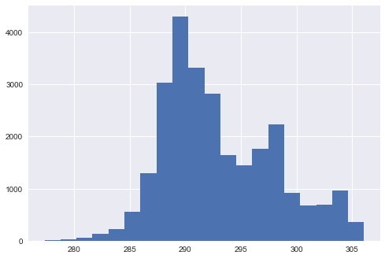

```python
h = plt.hist(arr.compressed(), 20)
```

As we look closer at the Cal-Adapt API, the following will ease working with time series raster data. It will request an entire time series for any geometry and return a Pandas `DataFrame` object.

```python
def to_fahren(val):
    return (val - 273.15) * 9 / 5 + 32


class CalAdaptRequest(object):
    series_url = 'http://api.cal-adapt.org/api/series/'

    def __init__(self, slug=None):
        self.slug = slug or 'tasmax_year_CanESM2_rcp85'
        self.params = {'pagesize': 94}

    def concat_features(self, features, field='id'):
        lst = []
        for feat in features:
            json = self.series(geom=feat['geometry'])
            series = self.to_frame(json)['image']
            if series.any():
                series.name = feat[field]
                lst.append(series)
        return pd.concat(lst, axis=1)

    def list_series_slugs(self):
        json = requests.get(self.series_url, params=self.params).json()
        return [row['slug'] for row in json['results']]

    def series(self, geom=None):
        url = '%s%s/rasters/' % (self.series_url, self.slug)
        if geom:
            params = dict(self.params, g=geom.wkt)
            if isinstance(geom, (sg.Polygon, sg.MultiPolygon)):
                params['stat'] = 'mean'
        return requests.get(url, params=params).json()

    def series(self, geom=None, dates=None):
        if dates:
            url = os.path.join(self.series_url, self.slug, *dates)
        else:
            url = os.path.join(self.series_url, self.slug, 'rasters/')
        if geom:
            params = dict(self.params, g=geom.wkt)
            if isinstance(geom, (sg.Polygon, sg.MultiPolygon)):
                params['stat'] = 'mean'
        return requests.get(url, params=params).json()

    def to_frame(self, json):
        df = pd.DataFrame.from_records(json['results'])
        df['image'] = to_fahren(pd.to_numeric(df['image']))
        df['event'] = pd.to_datetime(df['event'], format='%Y-%m-%d')
        df.set_index('event', inplace=True)
        return df.dropna()
```

```python
req = CalAdaptRequest()
records_g = [dict(rec, geometry=sg.Point(rec['decimalLongitude'], rec['decimalLatitude']))
             for rec in records]
df = req.concat_features(records_g, 'gbifID')
```

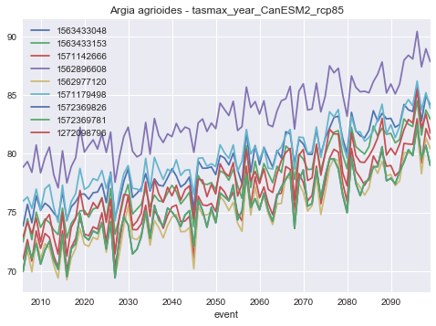

```python
df.iloc[:,:9].plot()
plt.title('Argia agrioides - %s' % req.slug)
```

We can map the projected means for for occurrence locations.

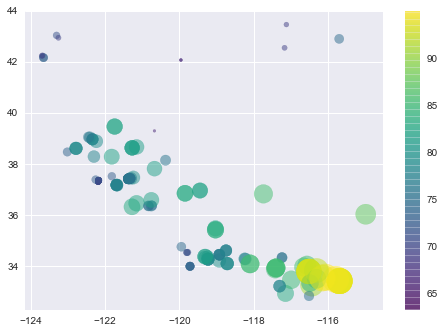

```python
tmax_means = df.mean(axis=0)
# Filter GBIF records where we have climate data.
records_rvals = [rec for rec in records_g if rec['gbifID'] in tmax_means.index]
coords = [(r['decimalLongitude'], r['decimalLatitude']) for r in records_rvals]
xs2, ys2 = zip(*coords)
#plt.scatter(xs2, ys2, c=tmax_means, cmap='viridis', alpha=0.5)
norm = mpl.colors.Normalize()
size = np.pi * (15 * norm(tmax_means)) ** 2
plt.scatter(xs2, ys2, c=tmax_means, s=size, cmap='viridis', alpha=0.5)
plt.colorbar()
```

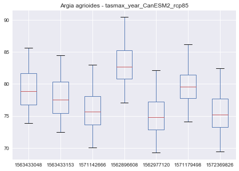

```python
#plt.figure(figsize=(12, 6))
df.iloc[:,:7].plot.box()
plt.title('Argia agrioides - %s' % req.slug)
```

Taking a look at minimum temperatures now, here are the temperature distributions by decade.

```python
dfs = []
names = ('tasmin_year_CanESM2_rcp45', 'tasmin_year_CanESM2_rcp85')
for name in names:
    req = CalAdaptRequest(name)
    dfs.append(req.concat_features(records_g, 'gbifID'))
```

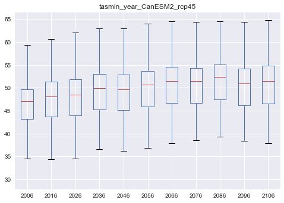

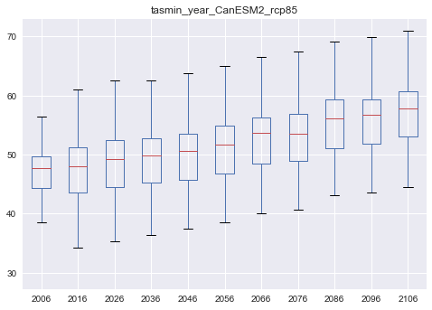

```python
for name, df in zip(names, dfs):
    t = df.resample('10A').mean().transpose()
    t.columns = t.columns.year
    t.plot.box()
    plt.title(name)
```

Make plots for historical and projected temperatures at three station locations.

```python
dfstns_lst = []
names = ('tasmax_year_CanESM2_historical', 'tasmax_year_CanESM2_rcp85')
for name in names:
    req = CalAdaptRequest(name)
    d = req.concat_features(stn_features)
    dfstns_lst.append(d)
    #d.plot()
    #plt.title(name)
dfstns = pd.concat(dfstns_lst)
```

```python
dfstns.describe()
```

|  | Hopland | Blodgett | Sagehen |
| --- | --- | --- | --- |
| count | 150.000000 | 150.000000 | 150.000000 |
| mean | 73.954559 | 71.490989 | 59.177320 |
| std | 3.823510 | 4.028578 | 4.083195 |
| min | 66.755128 | 64.090596 | 51.751210 |
| 25% | 70.751996 | 68.179744 | 55.762744 |
| 50% | 73.386036 | 71.171724 | 58.580037 |
| 75% | 76.625273 | 74.409852 | 62.291575 |
| max | 83.219349 | 81.009248 | 68.748762 |

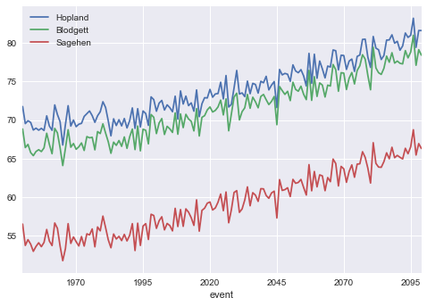

```python
dfstns.plot()
```

```python
# Decadal average and difference from 20 years prior.
dfstns.resample('10A').mean().diff(periods=2).dropna()
```

| event | Hopland | Blodgett | Sagehen |
| --- | --- | --- | --- |
| 1970-12-31 | -1.996913 | -2.030123 | -2.034525 |
| 1980-12-31 | 1.298666 | 1.139791 | 1.069217 |
| 1990-12-31 | -0.024911 | 0.283290 | 0.288138 |
| 2000-12-31 | 0.340087 | 0.863309 | 0.736968 |
| 2010-12-31 | 2.248330 | 2.235538 | 2.045231 |
| 2020-12-31 | 1.536509 | 1.872605 | 2.223111 |
| 2030-12-31 | 1.777258 | 2.258943 | 2.408269 |
| 2040-12-31 | 1.658831 | 1.816542 | 1.791623 |
| 2050-12-31 | 1.262038 | 1.139938 | 1.201976 |
| 2060-12-31 | 2.258954 | 1.987214 | 2.076378 |
| 2070-12-31 | 2.487662 | 2.375013 | 2.535040 |
| 2080-12-31 | 1.733868 | 1.909933 | 1.771419 |
| 2090-12-31 | 2.252422 | 2.357897 | 2.214294 |
| 2100-12-31 | 2.733526 | 2.487969 | 2.507936 |

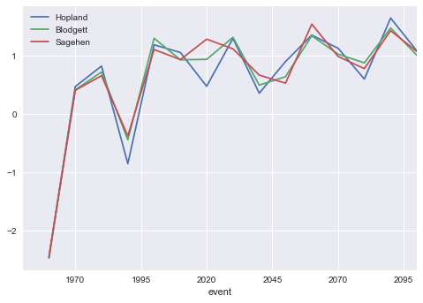

```python
dfstns.resample('10A').mean().diff().plot()
```